# Introduction to Statistics with R

# NHST: PART 1 (the practical part)

## Two-sample t-test

We draw two samples from two different populations. We assume that both populations are equally and normally distributed. We simulate a difference in means.

```r
Group <- c(rep("A", 1000), rep("B", 1000))
Height <- c(rnorm(1000, 180, 10), rnorm(1000, 160, 10))
MyData <- data.frame(Group, Height)
head(MyData)
```

```
  Group   Height
1     A 168.4513
2     A 177.7299
3     A 186.1509
4     A 179.5015
5     A 177.2923
6     A 187.5372
```

## Two-sample t-test

We visualize the two distributions by means of overlapping histograms.

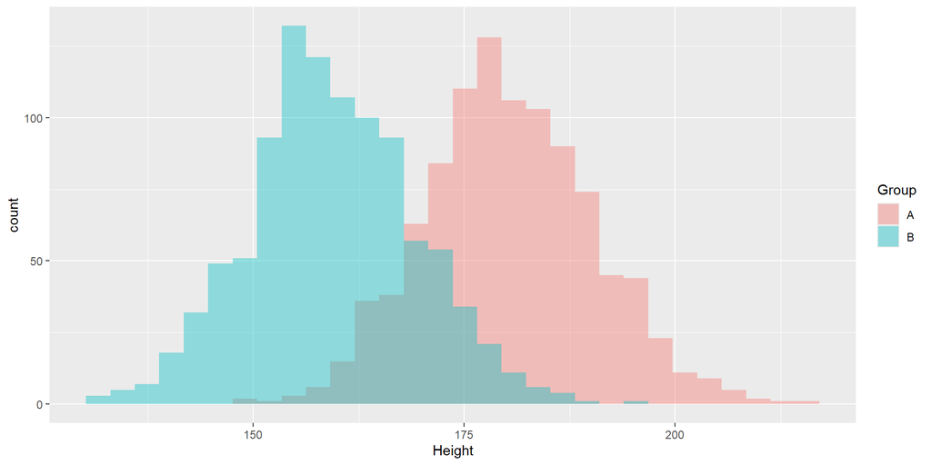

```r
ggplot(MyData, aes(x=Height, fill=Group)) +
  geom_histogram(position="identity", alpha=0.4)
```

## Two-sample t-test

Same data, different visualisation.

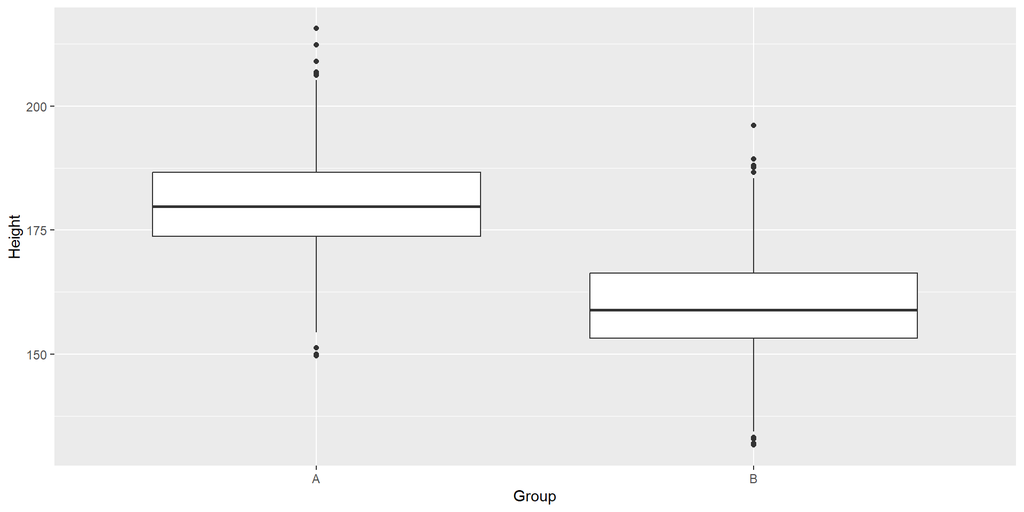

```r
ggplot(MyData, aes(x=Group, y=Height)) +
  geom_boxplot()
```

## Two-sample t-test

```r
t.test(MyData$Height ~ MyData$Group, var.equal=TRUE)
```

```
    Two Sample t-test

data:  MyData$Height by MyData$Group
t = 47.036, df = 1998, p-value < 2.2e-16
alternative hypothesis: true difference in means between group A and group B is not equal to 0
95 percent confidence interval:
 19.96607 21.70347
sample estimates:
mean in group A mean in group B
       180.2964        159.4616
```

## One-sample t-test

```r
mean(MyData$Height)
```

```
[1] 169.879
```

```r
t.test(MyData$Height, mu = 170)
```

```
    One Sample t-test

data:  MyData$Height
t = -0.37641, df = 1999, p-value = 0.7067
alternative hypothesis: true mean is not equal to 170
95 percent confidence interval:
 169.2486 170.5094
sample estimates:
mean of x
  169.879
```

## Exercise 9

Is the average duration of the DRESS vowel different from 110 ms? Important: First, you need to take a subset from the data, so that you only look at the DRESS vowel. Use this code to create a subset:

```r
dress <- subset(accent, Vowel == "DRESS") # "accent" is my object; you may have a different name.
head(dress)
```

Then perform the one sample t-test.

## Chi Squared t-test

We use data from an experiment on the dyslexia font. We load the data and tabulate the variable Dyslexi in relation to preferred Font.

```r
dyslexia <- read.csv2("dyslex.csv")
tbl <- table("Preferred font" = dyslexia$Preference, # rows
             "Dyslexic" = dyslexia$Dyslexi)          # columns
tbl
```

```
               Dyslexic
Preferred font  no yes
  Arial         53  29
  Dyslexie      48  26
  TimesNewRoman 14   2
```

## Clustered barplot

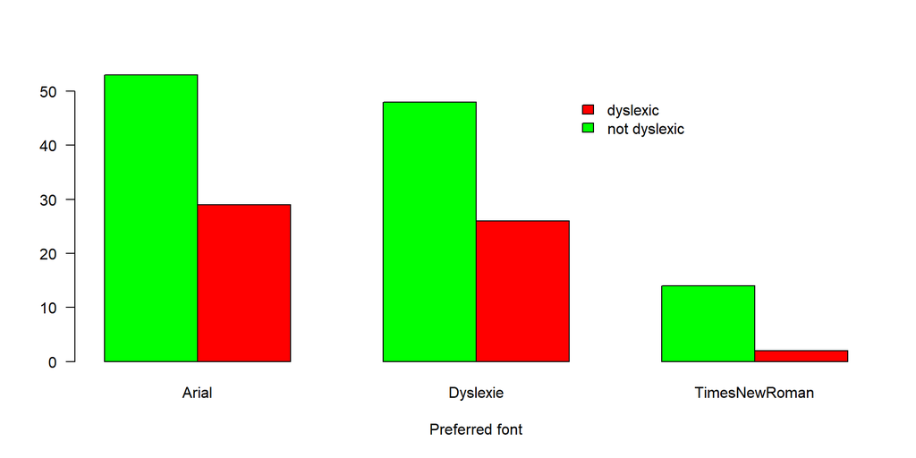

```r
tbl <- table(dyslexia$Dyslexi, dyslexia$Preference) # reversed order!
barplot(tbl,
        beside = TRUE,
        col=c("green", "red"),
        las=1,
        xlab = "Preferred font")
legend(6, 50, legend=c("dyslexic", "not dyslexic"),
       box.lty=0, cex=1, fill=c("red", "green"))
```

## Chi squared test

```r
chisq.test(tbl)
```

```
    Pearson's Chi-squared test

data:  tbl
X-squared = 3.3926, df = 2, p-value = 0.1834
```

No evidence is found that being dyslectic has an effect on the font preference of the readers.

## Exercise 10

Possessive alternation in English:

1. Kim’s book
2. the book of Kim

Is there an association with the final sibilant?

3. the wheels of the bus
4. $^?$the bus’s wheels

## Exercise 10

For this exercise, you examine `written_genitive_tokens_Brown_Frown.txt` from Grafmiller (2023). Open the data and select the variables `Type` and `Final_Sibilant`. Here is some example code that you could use:

```r
gen <- read.delim("written_genitive_tokens_Brown_Frown.txt",
                  stringsAsFactors=TRUE)
gen <- gen[ , c("Type", "Final_Sibilant")]
```

1. Crosstabulate `Type` and `Final_Sibilant`.
2. Evaluate the association between both variables by means of a chi-squared test.
3. Interpret your result.

## Simple linear regression

The `gcookbook::heightweight` dataset contains different body measurements

```r
library(gcookbook) # the data comes from the gcookbook package
str(heightweight)
```

```
'data.frame':   236 obs. of  5 variables:
 $ sex     : Factor w/ 2 levels "f","m": 1 1 1 1 1 1 1 1 1 1 ...
 $ ageYear : num  11.9 12.9 12.8 13.4 15.9 ...
 $ ageMonth: int  143 155 153 161 191 171 185 142 160 140 ...
 $ heightIn: num  56.3 62.3 63.3 59 62.5 62.5 59 56.5 62 53.8 ...
 $ weightLb: num  85 105 108 92 112 ...
```

## Data exploration

```r
summary(heightweight)
```

```
 sex        ageYear         ageMonth        heightIn        weightLb
 f:111   Min.   :11.58   Min.   :139.0   Min.   :50.50   Min.   : 50.5
 m:125   1st Qu.:12.33   1st Qu.:148.0   1st Qu.:58.73   1st Qu.: 85.0
         Median :13.58   Median :163.0   Median :61.50   Median :100.5
         Mean   :13.67   Mean   :164.1   Mean   :61.34   Mean   :101.0
         3rd Qu.:14.83   3rd Qu.:178.0   3rd Qu.:64.30   3rd Qu.:112.0
         Max.   :17.50   Max.   :210.0   Max.   :72.00   Max.   :171.5
```

- Let’s look at the relationship between Age (in years) and Height (in inches).
- What do you expect? (the data involves teenagers)

## Scatterplot with linear regression line

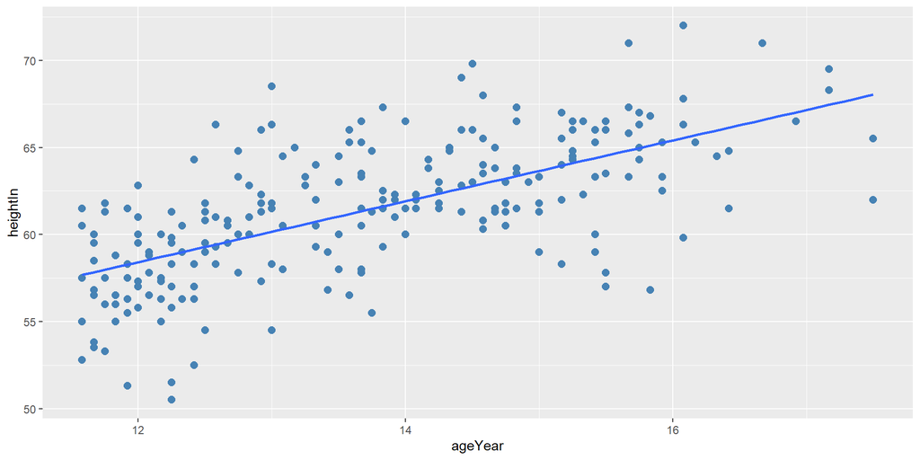

```r
p <- ggplot(heightweight, aes(x=ageYear, y=heightIn)) +
  geom_point(col="steelblue", size=2.5) +
  geom_smooth(method=lm, se=FALSE)
p
```

## Simple regression model

```r
mdl <- lm(heightIn ~ ageYear, data = heightweight)
summary(mdl)
```

```
Call:
lm(formula = heightIn ~ ageYear, data = heightweight)

Residuals:
    Min      1Q  Median      3Q     Max
-8.3517 -1.9006  0.1378  1.9071  8.3371

Coefficients:
            Estimate Std. Error t value Pr(>|t|)
(Intercept)  37.4356     1.8281   20.48   <2e-16 ***
ageYear       1.7483     0.1329   13.15   <2e-16 ***
---
Signif. codes:  0 '***' 0.001 '**' 0.01 '*' 0.05 '.' 0.1 ' ' 1

Residual standard error: 2.989 on 234 degrees of freedom
Multiple R-squared:  0.4249,    Adjusted R-squared:  0.4225
F-statistic: 172.9 on 1 and 234 DF,  p-value: < 2.2e-16
```

## Simple regression model

> There is a significant effect of Age on the average increase in height (t = 13, P-value < 0.001), with an average increase of 1.7 inches per year.

## Assumptions

```r
library(patchwork)
library(see)
library(performance)
check_model(mdl)
```

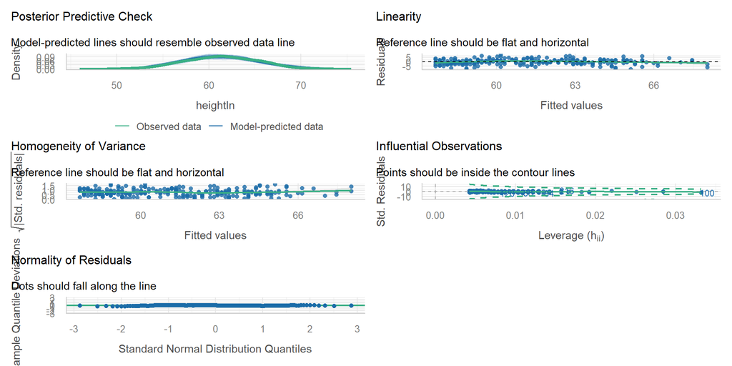

## Exercise 11

1. Open the dataset `Videolang.csv` .
2. Visualise the relation between `Posttest` and `Pretest` with a scatterplot.
3. fit a simple regression model with `Pretest` as a predictor and `Posttest` as the outcome.
4. Interpret the model estimates.

# NHST: PART 2 (the more theoretical part)

## Two-sample t-test

- Data: We create a mock dataset with Receptive vocabulary scores for the years 2000 and 2020.
- Question: is there a significant difference between the two means?

## Mock data: simulation

- 2020: $\mu=66$, $\sigma=16$
- 2000: $\mu=60$, $\sigma=16$

```r
set.seed(12)
Group <- as.factor(c(rep("2020", 60),
                     rep("2000", 60)))
Score <- c(rnorm(n = 60, mean = 66, sd = 16),
           rnorm(n = 60, mean = 60, sd = 16))
Test <- data.frame(Group, Score)
```

## Data: descriptive statistics

```r
library(tidyverse)
Test |> group_by(Group) |>
  summarise(Mean = round(mean(Score), 2),
            VAR = round(var(Score), 2),
            SD = round(sd(Score), 2))
```

[output not shown]

## Data: visualisation

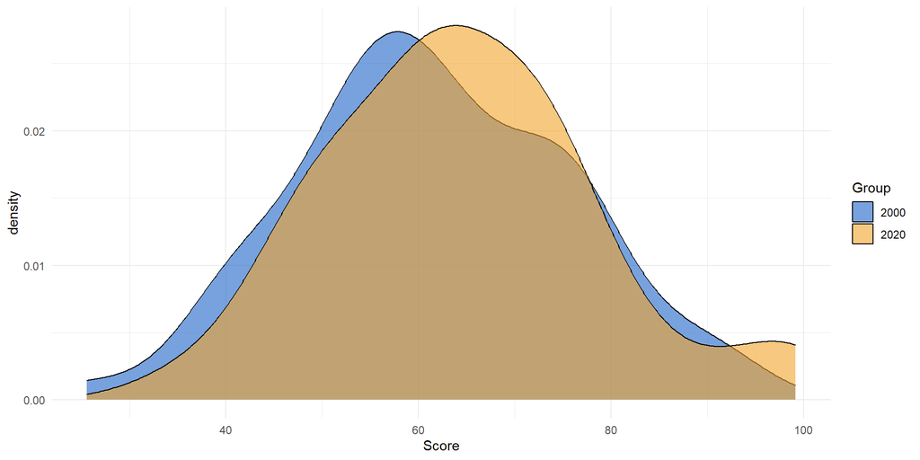

```r
ggplot(Test, aes(x = Score, fill = Group)) +
  geom_density(alpha = 0.6) +
  scale_fill_manual(values=c("#1E64C8", "#F1A42B")) +
  theme_minimal()
```

## Null and alternative hypotheses

- $H_0$: $\mu_{2000}=\mu_{2020}$
- $H_A$: $\mu_{2000}\neq\mu_{2020}$

  Or:
- $H_A$: $\mu_{2000}>\mu_{2020}$
- $H_A$: $\mu_{2000}<\mu_{2020}$

## Significance level

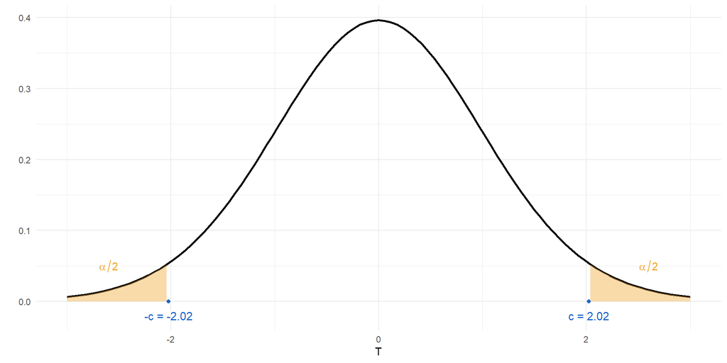

## Decision rules

- We reject the null hypothesis and accept the alternative hypothesis if the test statistic (the outcome of the statistical test, as explained in the next paragraph) is greater than the critical value.
- We reject the null hypothesis and accept the alternative hypothesis if the p-value is smaller than the significance level.

## two-sample t-test (equal variances assumed)

| Population | Parameters | Sample | Estimators |
| --- | --- | --- | --- |
| 1 | $\mu_1,\sigma_1$ | 1 | $\bar{X}_1,s_1$ |
| 2 | $\mu_2,\sigma_2$ | 2 | $\bar{X}_2,s_2$ |

## Test statistic

$$T=\frac{(\bar{X_1}-\bar{X_2})-(\mu_1-\mu_2)}{s_p\sqrt{\frac{1}{n_1}+\frac{1}{n_2}}}\sim t_{n_1+n_2-2}$$

## R: t.test()

```r
t.test(Score ~ Group,
             data = Test,
             alternative = "two.sided",
             var.equal = TRUE)
```

```
    Two Sample t-test

data:  Score by Group
t = -1.1357, df = 118, p-value = 0.2584
alternative hypothesis: true difference in means between group 2000 and group 2020 is not equal to 0
95 percent confidence interval:
 -7.982992  2.163870
sample estimates:
mean in group 2000 mean in group 2020
          61.52997           64.43953
```

## P-value

```r
pt(q = 1.13,
   df = 118,
   lower.tail = FALSE)*2
```

```
[1] 0.260768
```

## P-value

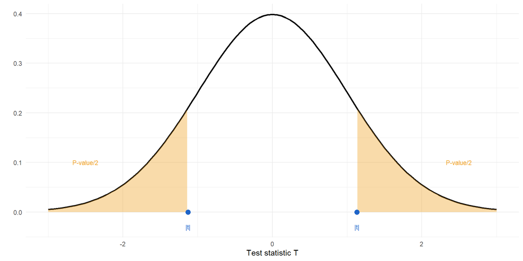

## Significance level $\alpha$

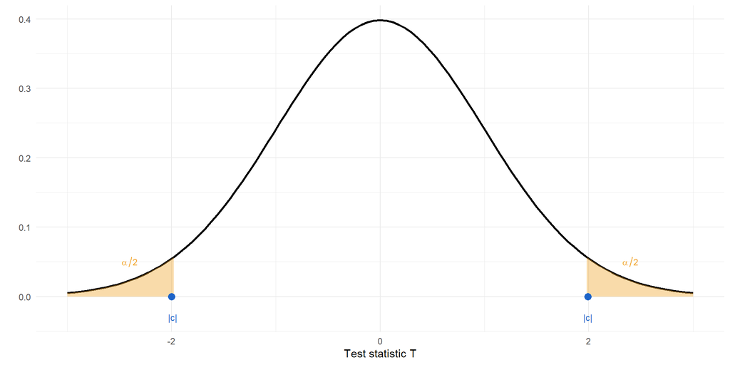

## Decision

There are basically two ways to decide whether the result of the statistical test is statistically significant:

- compare the P-value with $5\%$ (if P-value is smaller, then the test is significant)
- compare the test statistic with the critical value $c$ (if the test statistic is larger, then the test is significant)

## Chi-squared test

Question: is there a significant association between two categorical variables?

## Data: possessive alternation in English

1. Kim’s book
2. the book of Kim

## Effect of final sibilant

1. the wheels of the bus
2. the bus’s wheels

## Grafmiller 2023

Source: (Grafmiller 2023)

```r
gen <- read.delim("written_genitive_tokens_Brown_Frown.txt",
                  stringsAsFactors=TRUE)
```

```r
gen <- gen[ , c("Type",
                "Final_Sibilant")]
head(gen)
```

```
  Type Final_Sibilant
1    s              N
2   of              N
3   of              N
4    s              N
5   of              Y
6   of              N
```

## Crosstable

```r
table("final sibilant" = gen$Final_Sibilant, "Type" = gen$Type)
```

```
              Type
final sibilant   of    s
             N 2229 1754
             Y  874  241
```

## Data: visualisation

```r
library(dplyr)
tt <- gen |>
  select(Final_Sibilant, Type) |>
  group_by(Final_Sibilant, Type) |>
  summarize(n = n())
ggplot(data=tt, aes(x=Final_Sibilant, y=n, fill=Type)) +
  geom_col(position=position_dodge()) +
  scale_fill_manual('Type',
                    labels=c('of', 's'),
                    values=c('#F1A42B','#1E64C8')) +
  scale_x_discrete(name ="Final sibilant",
                   labels=c("absent","present")) +
  theme_minimal()
```

## Data: visualisation

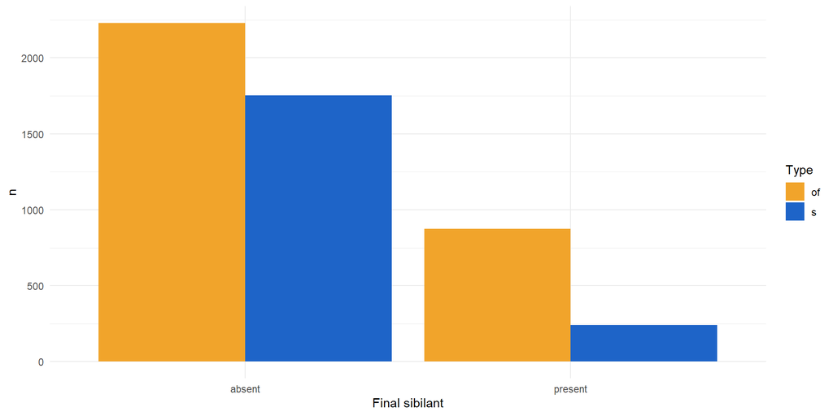

## Chi-squared test

|  | A1 | A2 |
| --- | --- | --- |
| B1 | 20 | 20 |
| B2 | 20 | 20 |

|  | A1 | A2 |
| --- | --- | --- |
| B1 | 40 | 0 |
| B2 | 0 | 40 |

## Hypotheses

- $H_0$: the two variables are indepedent
- $H_A$: the two variables are not independent

## Test statistic

$$X^2=\sum \frac{(f_o-f_e)^2}{f_e}$$

- $f_o$: observed frequenties
- $f_e$: expected frequencies

## Expected frequencies

$$f_{e11}=\frac{\text{row 1 total}*\text{column 1 total}}{\text{total number of observations}}$$

## Expected frequencies

```r
tt <- table(gen$Final_Sibilant, gen$Type)
chisq.test(tt)$exp
```

```
           of         s
  N 2424.3329 1558.6671
  Y  678.6671  436.3329
```

## Observed vs. Expected

Observed:

```r
table(gen$Final_Sibilant, gen$Type)
```

```
      of    s
  N 2229 1754
  Y  874  241
```

Expected:

```r
round(chisq.test(tt)$exp, 0)
```

```
      of    s
  N 2424 1559
  Y  679  436
```

## Residuals

##### Unstandardized

```r
chisq.test(tt)$res
```

```
           of         s
  N -3.967155  4.947646
  Y  7.498026 -9.351179
```

##### Standardized

```r
chisq.test(tt)$stdres
```

```
           of         s
  N -13.56033  13.56033
  Y  13.56033 -13.56033
```

## Teststatistic

$$\begin{split}
T&=\frac{(2229-2424)^2}{2424}+\frac{(1754-1559)^2}{1559}+\frac{(874-679)^2}{679}+\frac{(241-436)^2}{436}\\
&=183
\end{split}$$

## P-value

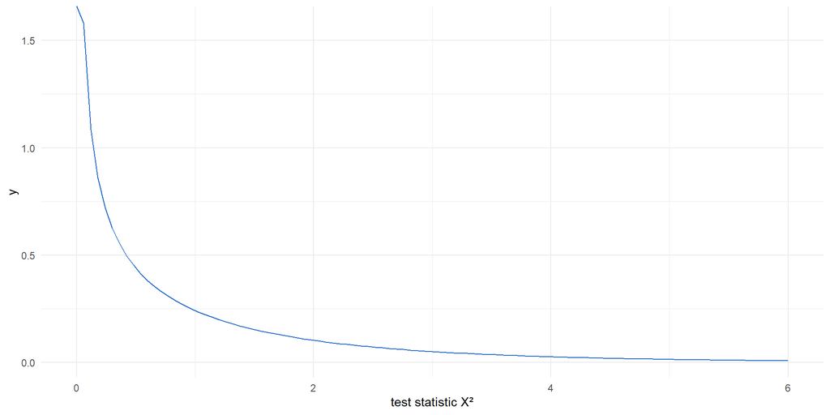

## Critical value c

```r
qchisq(p = 0.05, df = 1, lower.tail = FALSE)
```

```
[1] 3.841459
```

$183$ is much larger!!

## R: chisq.test()

```r
tt <- table(gen$Final_Sibilant, gen$Type)
chisq.test(tt)
```

```
    Pearson's Chi-squared test with Yates' continuity correction

data:  tt
X-squared = 182.94, df = 1, p-value < 2.2e-16
```

- “X-squared” = test statistic
- “df” = degrees of freedom

## Chi squared distributions

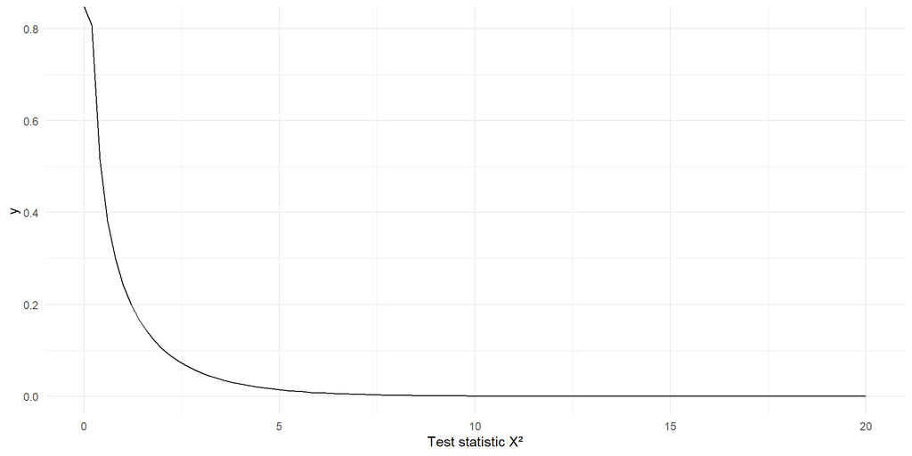

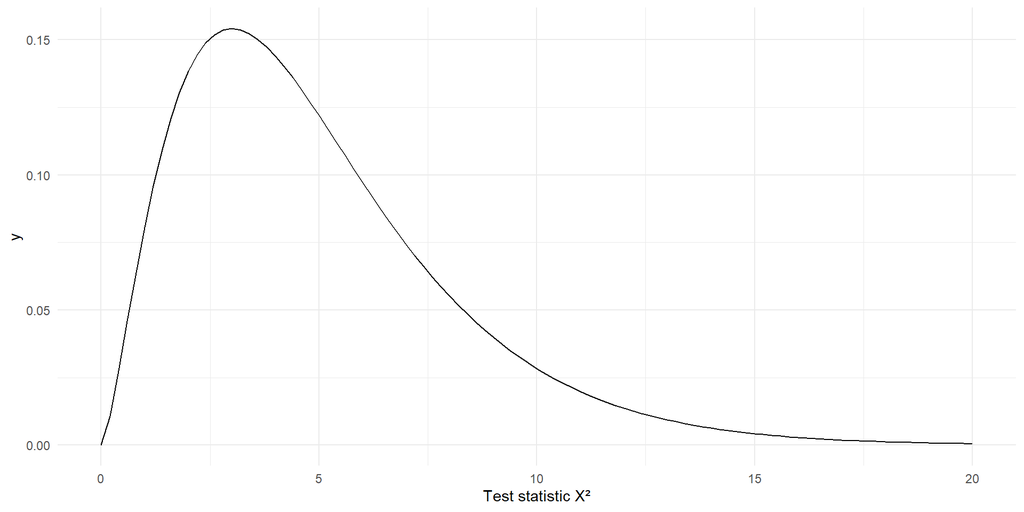

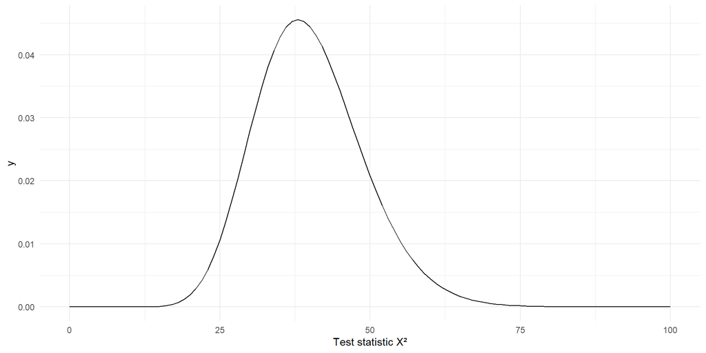

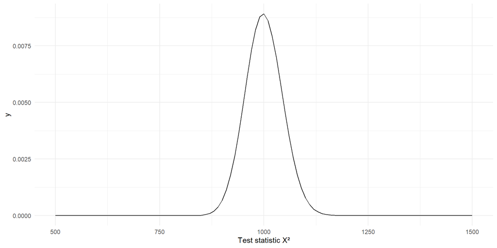

## Effect size: Cramer’s V

Strong evidence $\neq$ strong effect!

$$\text{Cramer's V}=\sqrt{\frac{X²}{N*min(c-1,r-1)}}$$

- N = number of observations
- c = number of columns
- r = number of rows
- min(c-1,r-1): the smallest number of the couple

## Example

$$\begin{split}
V&=\sqrt{\frac{X²}{N*min(c-1,r-1)}}\\
&=\sqrt{\frac{183}{5098*min(2-1,2-1)}}\\
&=\sqrt{\frac{183}{5098}}\\
&=0.19
\end{split}$$

## Interpretation Cramér’s V

Een effectsterkte van $19\%$ kan beschouwd worden als een zwakke associatie, op basis van de volgende interpretatie:

- $V=1$: perfect association
- $V=0$: no association
- $V<0.25$: weak association
- $0.25<V<0.75$: moderate association
- $V>0.75$: strong association

## Final assignment

Consider the `Falsebeginners` dataset (De Wilde, Brysbaert & Eyckmans 2019).

| ID | Variable | Description |
| --- | --- | --- |
| 1 | Student | A unique identifier for each student |
| 2 | School | A unique identifier for each school |
| 3 | Class | A unique identifier for each class |
| 4 | PPVT | Score for the Peabody Picture Vocabulary Test (PPVT). Maximum score = 120 |
| 5 | Speaking | Score for the speaking test. Maximum score = 20 |
| 6 | Listening | Score for the listening test. Maximum score = 25 |
| 7 | ReadingWriting | Score for the reading and writing tests. Maximum score = 50 |
| 8 | Attitude | Attitude of student towards English: Positive vs. Negative |
| 9 | L1 | L1: Dutch vs. Multilingual |
| 10 | Sex | Sex of student: Male vs. Female |

## Questions

1. Load the Falsebeginners dataset.
2. Provide a univariate summary of every variable.
3. Visualize the distribution of PPVT scores using a blue histogram.
4. Visualize the distribution of PPVT scores using a green boxplot.
5. Create a clustered boxplot of PPVT scores by Sex.
6. Visualize the distribution of PPVT scores by Sex using overlapping histograms in ggplot2.
7. Perform a t-test to determine if there is a significant difference in PPVT scores between male and female students.
8. Create a table summarizing the relationship between L1 and Sex.
9. Use a chi-squared test to assess whether L1 is associated with Sex.
10. Create a scatterplot to visualize the relationship between Speaking and Listening scores, and add a regression line.
11. Fit a simple linear regression model with Speaking as the predictor and Listening as the outcome variable.

## References

De Wilde, Vanessa, Marc Brysbaert & June Eyckmans. 2019. Learning english through out-of-school exposure. Which levels of language proficiency are attained and which types of input are important? *Bilingualism: Language and Cognition* 23(1). 171–185. https://doi.org/10.1017/s1366728918001062.

Grafmiller, Jason. 2023. The genitive alternation in 1960s and 1990s American English: Data from the Brown and Frown corpora. DataverseNO. https://doi.org/10.18710/R7HM8J.

Verbeke, Gil & Wout Van Praet. 2025. Replication Data for: The interplay between prosodic prominence and boundary strength in the production of English checked steady-state vowels. DataverseNO. https://doi.org/10.18710/QRXULF.